# Full pattern summation of XRPD data

This document describes methods for quantitative analysis implemented within **powdR** via a range of reproducible examples that use open source data from the package.

One of the most powerful properties of XRPD data is that the intensities of crystalline (e.g., quartz, calcite and gypsum), disordered (e.g., clay minerals), and amorphous (e.g., volcanic glass and organic matter) signals within a diffractogram can be related to their concentrations within the mixture. This principal facilitates the quantification of phase concentrations from XRPD data.

Of the approaches available for quantitative XRPD analysis, the simple Reference Intensity Ratio (RIR) method has consistently proven accurate. A RIR is a measure of the diffracting power of a phase relative to that of a standard (most often corundum, Al<sub>2</sub>O<sub>3</sub>), usually measured in a 50:50 mixture by weight. The RIR of a detectable phase within a mixture is required for its quantification.

A given diffractogram can be modeled as the sum of pure diffractograms for all detectable phases, each scaled by different amounts (scaling factors). By combining these scaling factors with RIRs, phase concentrations can be calculated. Hereafter this approach is referred to as full pattern summation. Full pattern summation is particularly suitable for mixtures containing crystalline mineral components in combination with disordered and/or X-ray amorphous phases (e.g. soil), and further details on its implementation in **powdR** are provided in Butler and Hillier (2021b).

# 1 Full pattern summation with **powdR**

## 1.1 The `powdRlib` object

[video not shown]

A key component of the full pattern summation functions within **powdR** is the library of reference patterns. These are stored within a `powdRlib` object created from two basic components using the `powdRlib()` constructor function. The first component, specified via the `xrd_table` argument of `powdRlib()`, is a data frame of the count intensities of the reference patterns, with their 2θ axis as the first column. The column for a given reference pattern must be named using a unique identifier (a phase ID). An example of such a format is provided in the `minerals_xrd` data:

```r
library(powdR)

data(minerals_xrd)

head(minerals_xrd)
```

```
#>       tth QUA.1 QUA.2 FEL ORT SAN ALB OLI DOL.1 DOL.2  ILL KAO GOE.1 GOE.2  ORG
#> 1 4.00973    69    91 546 599 638 308 343   268   362 3078 525  3549 10000 3225
#> 2 4.04865    69    92 524 570 609 294 332   256   345 2960 500  3511  9592 3180
#> 3 4.08757    64    86 505 555 582 286 328   250   343 2888 486  3401  9323 3135
#> 4 4.12649    64    83 512 543 558 277 310   247   327 2753 474  3290  9042 3092
#> 5 4.16541    62    83 478 518 536 275 304   241   318 2718 478  3194  9248 3050
#> 6 4.20433    60    81 459 514 517 261 298   228   314 2720 447  3113  8557 3010
```

The second component required to build a `powdRlib` object, specified via the `phases_table` argument of `powdRlib()`, is a data frame containing 3 columns in the following order.

1. `phase_id`: a string of unique IDs corresponding to the names of each reference pattern in the data provided to the `xrd_table` argument outlined above.
2. `phase_name`: the name of the phase group that this reference pattern belongs to (e.g. quartz, plagioclase, illite etc.).
3. `rir`: the reference intensity ratios of the reference patterns (relative to a known standard, usually corundum).

An example of the format required for the `phases_table` argument of `powRlib()` is provided in the `minerals_phases` data.

```r
data(minerals_phases)

minerals_phases
```

```
#>    phase_id     phase_name  rir
#> 1     QUA.1         Quartz 4.62
#> 2     QUA.2         Quartz 4.34
#> 3       FEL     K-feldspar 0.75
#> 4       ORT     K-feldspar 1.03
#> 5       SAN     K-feldspar 0.93
#> 6       ALB    Plagioclase 1.31
#> 7       OLI    Plagioclase 1.06
#> 8     DOL.1       Dolomite 2.35
#> 9     DOL.2       Dolomite 2.39
#> 10      ILL         Illite 0.22
#> 11      KAO      Kaolinite 0.91
#> 12    GOE.1       Goethite 0.93
#> 13    GOE.2       Goethite 0.37
#> 14      ORG Organic-Matter 0.07
```

Crucially, when building the `powdRlib` object, all phase IDs in the first column of the `phases_table` must match the column names of the `xrd_table` (excluding the name of the first column which is the 2θ axis), for example.

```r
identical(names(minerals_xrd[-1]),
          minerals_phases$phase_id)
```

```
#> [1] TRUE
```

Once created, `powdRlib` objects can easily be visualised using the associated `plot()` method (see `?plot.powdRlib`), which accepts the `wavelength`, `refs` and `interactive` arguments that are used to specify the X-ray wavelength, the reference patterns to plot, and the output format, respectively. In all cases where `plot()` is used in this document, the use of `interactive = TRUE` in the function call will produce an interactive html graph that can be viewed in RStudio or a web browser.

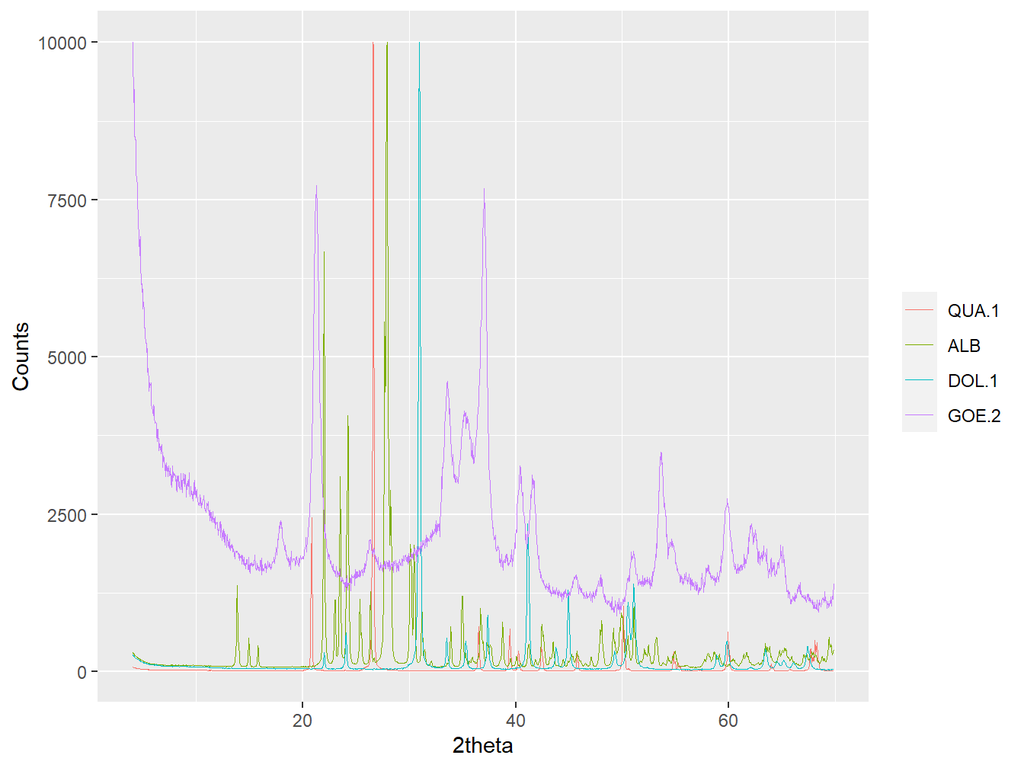

Figure 1.1: Plotting selected reference patterns from a powdRlib object.

```r
my_lib <- powdRlib(minerals_xrd, minerals_phases)

plot(my_lib, wavelength = "Cu",
     refs = c("ALB", "DOL.1",
              "QUA.1", "GOE.2"),
     interactive = FALSE)
```

### 1.1.1 Pre-loaded `powdRlib` objects

To accompany the `rockjock` reference library, a list of eight synthetic mixtures from the original RockJock program are also included in **powdR** in the `rockjock_mixtures` data [accessed via `data(rockjock_mixtures)`], and the known compositions of these mixtures provided in the `rockjock_weights` data [accessed via `data(rockjock_weights)`].

### 1.1.2 Subsetting a `powdRlib` object

Occasionally it may be useful to subset a reference library to a smaller selection. This can be achieved using `subset()`, which for `powdRlib` objects accepts three arguments: `x`, `refs` and `mode` (see `?subset.powdRlib`). The `x` argument specifies the `powdRlib` object to be subset, `refs` specifies the IDs and/or names of phases to select, and `mode` specifies whether these phases are kept (`mode = "keep"`) or removed (`mode = "remove"`).

```r
data(rockjock)

#Have a look at the phase IDs in rockjock
rockjock$phases$phase_id[1:10]
```

```
#>  [1] "CORUNDUM"                "BACK_POS"
#>  [3] "BACK_NEG"                "QUARTZ"
#>  [5] "ORDERED_MICROCLINE"      "INTERMEDIATE_MICROCLINE"
#>  [7] "SANIDINE"                "ORTHOCLASE"
#>  [9] "ANORTHOCLASE"            "ALBITE_CLEAVELANDITE"
```

```r
#Remove reference patterns from rockjock
rockjock_1 <- subset(rockjock,
                     refs = c("ALUNITE", #phase ID
                              "AMPHIBOLE", #phase ID
                              "ANALCIME", #phase ID
                              "Plagioclase"), #phase name
                     mode = "remove")

#Check number of reference patterns remaining in library
nrow(rockjock_1$phases)
```

```
#> [1] 157
```

```r
#Keep certain reference patterns of rockjock
rockjock_2 <- subset(rockjock,
                     refs = c("ALUNITE", #phase ID
                              "AMPHIBOLE", #phase ID
                              "ANALCIME", #phase ID
                              "Plagioclase"), #phase name
                     mode = "keep")

#Check number of reference patterns remaining
nrow(rockjock_2$phases)
```

```
#> [1] 11
```

### 1.1.3 Interpolating and merging `powdRlib` objects

Two `powdRlib` objects from different instruments can be interpolated and then merged using the `interpolate` and `merge` methods (see `?interpolate.powdRlib` and `merge.powdRlib`), respectively. For example, the `minerals` library can be merged with the `rockjock` library after interpolation using:

```r
#Load the minerals library
data(minerals)

#Check the number of reference patterns
nrow(minerals$phases)
```

```
#> [1] 14
```

```r
#Load the rockjock library
data(rockjock)

#Check the number of reference patterns
nrow(rockjock$phases)
```

```
#> [1] 168
```

```r
#interpolate minerals library onto same 2theta as rockjock
minerals_i <- interpolate(minerals, new_tth = rockjock$tth)

#merge the libraries
merged_lib <- merge(rockjock, minerals_i)

#Check the number of reference patterns in the merged library
nrow(merged_lib$phases)
```

```
#> [1] 182
```

In simpler cases where two libraries are already on the same 2θ axis and were measured using the same instrumental parameters, only the use of `merge()` would be required.

```r
#Load the afsis library
data(afsis)

identical(rockjock$tth, afsis$tth)
```

```
#> [1] TRUE
```

```r
rockjock_afsis <- merge(rockjock, afsis)
```

## 1.2 Full pattern summation with `fps()`

[video not shown]

Once you have a `powdRlib` reference library and diffractogram(s) loaded into R, you have everything needed for quantitative analysis via full pattern summation. Full pattern summation in **powdR** is provided via the `fps()` function, whilst an automated version is provided in `afps()`. Details on these functions are provided in Butler and Hillier (2021a) and Butler and Hillier (2021b).

`fps()` is specifically applied to `powdRlib` objects, and accepts a wide range of arguments that are detailed in the package documentation (see `?fps.powdRlib`). Here the `rockjock` and `rockjock_mixtures` data will be used to demonstrate the main features of `fps()` and the various ways in which it can be used.

### 1.2.1 Full pattern summation **with** an internal standard

Often samples are prepared for XRPD analysis with an internal standard of known concentration. If this is the case, then the `std` and `std_conc` arguments of `fps()` can be used to define the internal standard and its concentration (in weight %), respectively, which is then used in combination with the reference intensity ratios to compute phase concentrations. For example, all samples in the `rockjock_mixtures` data were prepared with 20 % corundum as the internal standard, thus this can be specified using `std = "CORUNDUM"` and `std_conc = 20` in the call to `fps()`. In addition, setting the `omit_std` argument to `TRUE` makes sure that the internal standard concentration will be omitted from the output and the phase concentrations recomputed accordingly. In such cases the phase specified as the internal standard can also be used in combination with the value specified in the `align` argument to ensure that the measured diffractogram is appropriately aligned on the 2θ axis. These principles are used in the example below, which passes the following seven arguments to `fps()`:

1. `lib` is used to define the `powdRlib` object containing the reference patterns and their RIRs.
2. `smpl` is used to define the data frame or `XY` object containing the sample diffractogram.
3. `refs` is used to define a string of phase IDs (`lib$phases$phase_id`) and/or phase names (`lib$phases$phase_names`) of the reference patterns to be used in the fitting process.
4. `std` is used to define the phase ID of the reference pattern to be used as the internal standard.
5. `std_conc` is used to define the concentration of the internal standard in weight %.
6. `omit_std` is used to define whether the internal standard is omitted from the output and phase concentrations recomputed accordingly.
7. `align` is used to define the maximum positive or negative shift in 2θ that is permitted during alignment of the sample to the reference pattern that is specified in the `std` argument.

```r
data(rockjock_mixtures)

fit1 <- fps(lib = rockjock,
            smpl = rockjock_mixtures$Mix5,
            refs = c("ORDERED_MICROCLINE",
                     "Plagioclase",
                     "KAOLINITE_DRY_BRANCH",
                     "MONTMORILLONITE_WYO",
                     "CORUNDUM",
                     "QUARTZ"),
            std = "CORUNDUM",
            std_conc = 20,
            omit_std = TRUE,
            align = 0.3)
```

```
#>
#> -Aligning sample to the internal standard
#> -Interpolating library to same 2theta scale as aligned sample
#> -Optimising...
#> -Removing negative coefficients and reoptimising...
#> -Removing negative coefficients and reoptimising...
#> -Computing phase concentrations
#> -Using internal standard concentration of 20 % to compute phase concentrations
#> -Omitting internal standard from phase concentrations
#> ***Full pattern summation complete***
```

Once computed, the `fps()` function produces a `powdRfps` object, which is a bundle of data in list format that contains the outputs (see `?fps.powdRlib`).

```r
summary(fit1)
```

```
#>                        Length Class      Mode
#> tth                    2992   -none-     numeric
#> fitted                 2992   -none-     numeric
#> measured               2992   -none-     numeric
#> residuals              2992   -none-     numeric
#> phases                    4   data.frame list
#> phases_grouped            2   data.frame list
#> obj                       3   -none-     numeric
#> weighted_pure_patterns    9   data.frame list
#> coefficients              9   -none-     numeric
#> inputs                   16   -none-     list
```

The phase concentrations can be accessed in the `phases` or `phases_grouped` data frames of the `powdRfps` object:

```r
#All phases
fit1$phases
```

```
#>               phase_id    phase_name       rir phase_percent
#> 1             CORUNDUM      Corundum 1.0000000            NA
#> 2               QUARTZ        Quartz 3.5404393     24.955000
#> 3   ORDERED_MICROCLINE    K-feldspar 0.9654312     40.098375
#> 4         ANORTHOCLASE   Plagioclase 0.5804293      3.612375
#> 5             ANDESINE   Plagioclase 0.8206422      2.969625
#> 6          LABRADORITE   Plagioclase 0.8113040      3.350375
#> 7            ANORTHITE   Plagioclase 0.5294816      2.485875
#> 8 KAOLINITE_DRY_BRANCH     Kaolinite 0.5812875      5.302750
#> 9  MONTMORILLONITE_WYO Smectite (Di) 0.3202779     12.908250
```

```r
#Phases grouped and summed by the phase name
fit1$phases_grouped
```

```
#>      phase_name phase_percent
#> 1      Corundum            NA
#> 2        Quartz      24.95500
#> 3    K-feldspar      40.09837
#> 4   Plagioclase      12.41837
#> 5     Kaolinite       5.30275
#> 6 Smectite (Di)      12.90825
```

Further, notice that when the concentration of the internal standard is specified then the phase concentrations do not necessarily sum to 100 %:

```r
sum(fit1$phases$phase_percent, na.rm = TRUE)
```

```
#> [1] 95.68263
```

It’s also possible to “close” the mineral composition so that the weight percentages sum to 100. This can be achieved in two ways:

1. By defining `closed = TRUE` in the `fps()` function call.
2. By applying the `close_quant()` function to the `powdRfps` output.

```r
fit1c <- close_quant(fit1)

sum(fit1c$phases$phase_percent, na.rm = TRUE)
```

```
#> [1] 100
```

### 1.2.2 Full pattern summation **without** an internal standard

In cases where an internal standard is not added to a sample, phase quantification can be achieved by assuming that all detectable phases can be identified and that they sum to 100 weight %. By setting the `std_conc` argument of `fps()` to `NA`, or leaving it out of the function call, it will be assumed that the sample has been prepared without an internal standard and the phase concentrations computed accordingly.

```r
fit2 <- fps(lib = rockjock,
            smpl = rockjock_mixtures$Mix5,
            refs = c("ORDERED_MICROCLINE",
                     "Plagioclase",
                     "KAOLINITE_DRY_BRANCH",
                     "MONTMORILLONITE_WYO",
                     "CORUNDUM",
                     "QUARTZ"),
            std = "CORUNDUM",
            align = 0.3)
```

```
#>
#> -Aligning sample to the internal standard
#> -Interpolating library to same 2theta scale as aligned sample
#> -Optimising...
#> -Removing negative coefficients and reoptimising...
#> -Removing negative coefficients and reoptimising...
#> -Computing phase concentrations
#> -Internal standard concentration unknown. Assuming phases sum to 100 %
#> ***Full pattern summation complete***
```

In this case the phase specified in the `std` argument is only used for 2θ alignment, and is always included in the computed phase concentrations.

```r
fit2$phases
```

```
#>               phase_id    phase_name       rir phase_percent
#> 1             CORUNDUM      Corundum 1.0000000       20.7155
#> 2               QUARTZ        Quartz 3.5404393       20.6782
#> 3   ORDERED_MICROCLINE    K-feldspar 0.9654312       33.2262
#> 4         ANORTHOCLASE   Plagioclase 0.5804293        2.9933
#> 5             ANDESINE   Plagioclase 0.8206422        2.4607
#> 6          LABRADORITE   Plagioclase 0.8113040        2.7762
#> 7            ANORTHITE   Plagioclase 0.5294816        2.0599
#> 8 KAOLINITE_DRY_BRANCH     Kaolinite 0.5812875        4.3940
#> 9  MONTMORILLONITE_WYO Smectite (Di) 0.3202779       10.6961
```

Furthermore, the phase concentrations computed using this approach will always sum to 100 %.

```r
sum(fit2$phases$phase_percent)
```

```
#> [1] 100.0001
```

### 1.2.3 Non-negative least squares

The fitted patterns resulting from full pattern summation are most commonly derived by minimising an objective function. This process is computationally intensive and can therefore prove slow when a large number of scaling coefficients (i.e. a large number of reference patterns) are used. As a fast alternative to this approach, non-negative least squares [NNLS; Mullen and van Stokkum (2012)] is also implemented in `fps()` and can be defined using the `solver` argument:

```r
#Create a timestamp
a <- Sys.time()

fit2_n <- fps(lib = rockjock,
              smpl = rockjock_mixtures$Mix5,
              refs = c("ORDERED_MICROCLINE",
                       "Plagioclase",
                       "KAOLINITE_DRY_BRANCH",
                       "MONTMORILLONITE_WYO",
                       "CORUNDUM",
                       "QUARTZ"),
              solver = "NNLS",
              std = "CORUNDUM",
              align = 0.3)
```

```
#>
#> -Aligning sample to the internal standard
#> -Interpolating library to same 2theta scale as aligned sample
#> -Applying non-negative least squares
#> -Computing phase concentrations
#> -Internal standard concentration unknown. Assuming phases sum to 100 %
#> ***Full pattern summation complete***
```

```r
#Calculate computation time
Sys.time() - a
```

```
#> Time difference of 0.2005031 secs
```

resulting in a computation time of less than half a second. Whilst the use of NNLS is fast, there is a small compromise in accuracy compared to the minimisation of an objective function (see Supplementary Material in Butler and Hillier 2021b).

## 1.3 Automated full pattern summation

[video not shown]

The selection of suitable reference patterns for full pattern summation can often be challenging and time consuming. An attempt to automate this process is provided in the `afps()` function, which can select appropriate reference patterns from a reference library and subsequently exclude reference patterns based on limit of detection estimates. Such an approach is considered particularly advantageous when quantifying high-throughput XRPD datasets that display considerable mineralogical variation such as the [Reynolds Cup](https://www.clays.org/reynolds/) (Butler and Hillier 2021a).

All of the principles and arguments outlined above for the `fps()` function also apply to the use of `afps()`. However, there are a few additional arguments for `afps()` that need to be defined:

1. `force` is used to specify phase IDs (`lib$phases$phase_id`) or phase names (`lib$phases$phase_name`) that must be retained in the output, even if their concentrations are estimated to be below the limit of detection or negative.
2. `lod` is used to define the limit of detection (LOD; in weight %) of the phase specified as the internal standard in the `std` argument. This limit of detection for the defined phase is then used in combination with the RIRs to estimate the LODs of all other phases Butler and Hillier (2021b).
3. `amorphous` is used to specify which, if any, phases should be treated as amorphous. This is used because the assumptions used to estimate the LODs of crystalline and disordered phases are not appropriate for amorphous phases.
4. `amorphous_lod` is used to define the LOD (in weight %) of the phases specified in the `amorphous` argument.

```r
#Produce the fit
a_fit1 <- afps(lib = rockjock,
               smpl = rockjock_mixtures$Mix5,
               std = "CORUNDUM",
               align = 0.3,
               lod = 1)
```

## 1.4 Additional `fps()` and `afps()` functionality

### 1.4.1 Shifting of reference patterns

Both `fps()` and `afps()` accept a `shift` argument, which when set to a value greater than zero results in optimisation of a small 2θ shift for each reference pattern in order to improve the quality of the fit. The value supplied to the `shift` argument defines the maximum (either positive or negative) shift that can be applied to each reference pattern before the shift is reset to zero.

This shifting process is designed to correct for small linear differences in the peak positions of the standards relative to the sample, which may result from a combination of instrumental aberrations, mineralogical variation and/or uncorrected errors in the library patterns. Whilst this shifting routine provides more accurate results, the process can substantially increase computation time.

### 1.4.2 Regrouping phases in `powdRfps` and `powdRafps` objects

Occasionally it can be useful to apply a different grouping structure to the phases quantified within a `powdRfps` or `powdRafps` object. This can be achieved using the `regroup` function (see `?regroup.powdRfps` and `?regroup.powdRafps`):

```r
#View the phases of the fit1 output
fit1$phases
```

```
#>               phase_id    phase_name       rir phase_percent
#> 1             CORUNDUM      Corundum 1.0000000            NA
#> 2               QUARTZ        Quartz 3.5404393     24.955000
#> 3   ORDERED_MICROCLINE    K-feldspar 0.9654312     40.098375
#> 4         ANORTHOCLASE   Plagioclase 0.5804293      3.612375
#> 5             ANDESINE   Plagioclase 0.8206422      2.969625
#> 6          LABRADORITE   Plagioclase 0.8113040      3.350375
#> 7            ANORTHITE   Plagioclase 0.5294816      2.485875
#> 8 KAOLINITE_DRY_BRANCH     Kaolinite 0.5812875      5.302750
#> 9  MONTMORILLONITE_WYO Smectite (Di) 0.3202779     12.908250
```

```r
#Load the rockjock regrouping structure
data(rockjock_regroup)

#View the first 6 rows
head(rockjock_regroup)
```

```
#>                  phase_id phase_name_grouped phase_name_grouped2
#> 1                CORUNDUM           Corundum            Non-clay
#> 2                BACK_POS         Background          Background
#> 3                BACK_NEG         Background          Background
#> 4                  QUARTZ             Quartz            Non-clay
#> 5      ORDERED_MICROCLINE         K-feldspar            Non-clay
#> 6 INTERMEDIATE_MICROCLINE         K-feldspar            Non-clay
```

```r
#Regroup the data in a_fit1 using the coarsest description
fit1_rg <- regroup(fit1, rockjock_regroup[c(1,3)])

#Check the regrouped data
fit1_rg$phases_grouped
```

```
#>   phase_name phase_percent
#> 1       Clay      18.21100
#> 2   Non-clay      77.47162
```

# 2 Plotting `powdRfps` and `powdRafps` objects

[video not shown]

Plotting results `powdRfps` and `powdRafps` objects, derived from `fps()` and `afps()`, respectively, is achieved using `plot()` (see `?plot.powdRfps` and `?plot.powdRafps`).

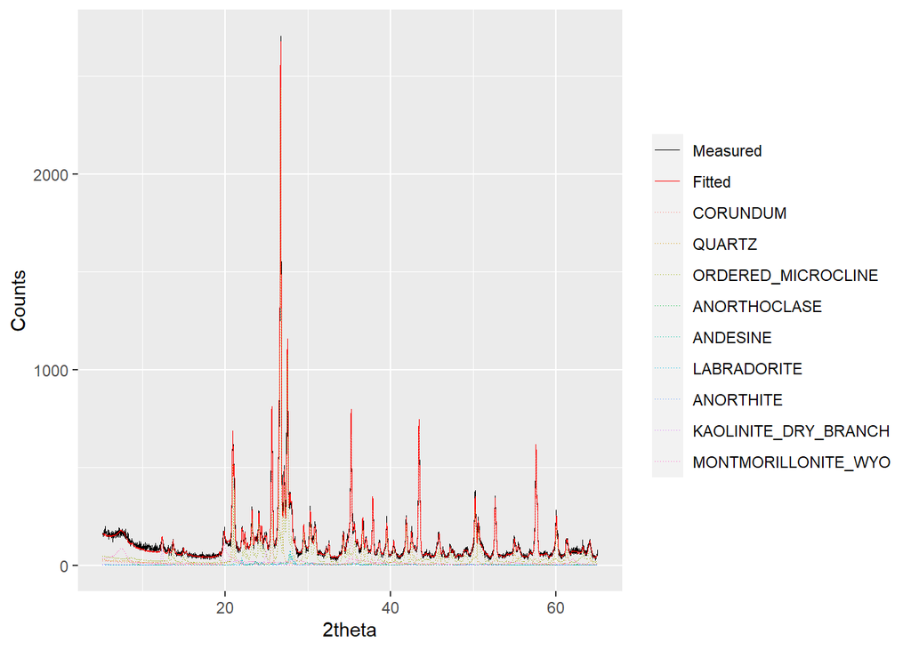

Figure 2.1: Example output from plotting a powdRfps or powdRafps object.

```r
plot(fit1, wavelength = "Cu", interactive = FALSE)
```

When plotting `powdRfps` or `powdRafps` objects the wavelength must be defined because it is required to compute d-spacings that are shown when `interactive = TRUE`.

In addition to above, plotting for `powdRfps` and `powdRafps` objects can be further adjusted by the `group`, `mode` and `xlim` arguments. When the `group` argument is set to `TRUE`, the patterns within the fit are grouped and summed according to phase names, which can help simplify the plot:

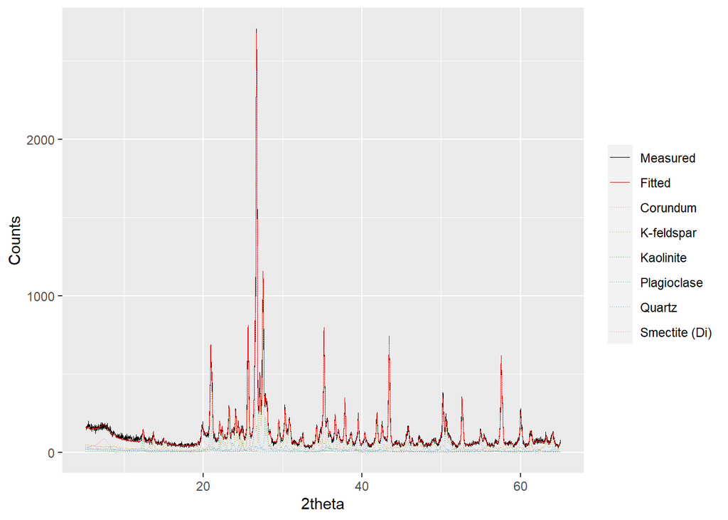

Figure 2.2: Plotting a powdRfps or powdRafps object with the reference patterns grouped.

```r
plot(fit1, wavelength = "Cu",
     group = TRUE,
     interactive = FALSE)
```

The `mode` argument can be one of `"fit"` (the default), `"residuals"` or `"both"`, for example:

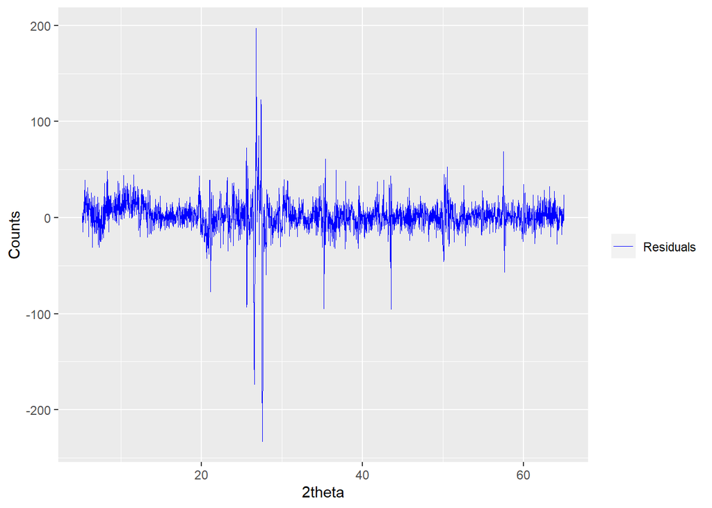

Figure 2.3: Plotting the residuals of a powdRfps or powdRafps object.

```r
plot(fit1, wavelength = "Cu",
     mode = "residuals",
     interactive = FALSE)
```

or alternatively both the fit and residuals can be plotted using `mode = "both"` and the 2θ axis restricted using the `xlim` argument:

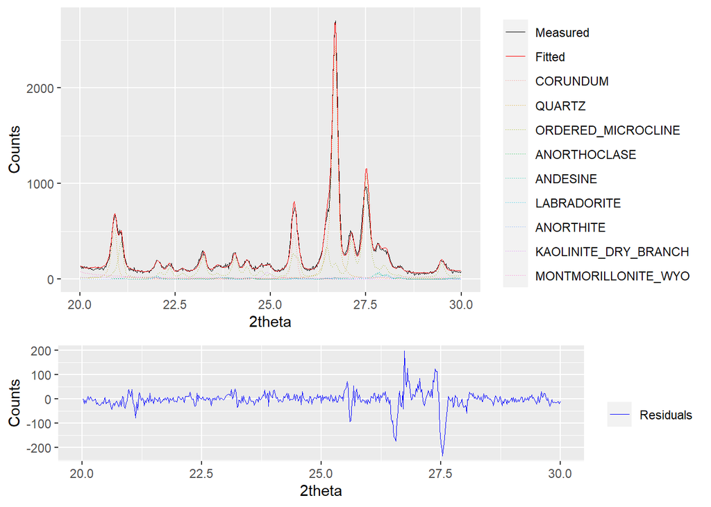

Figure 2.4: Plotting both the fit and residuals of a powdRfps or powdRafps object.

```r
plot(fit1, wavelength = "Cu",
     mode = "both", xlim = c(20,30),
     interactive = FALSE)
```

# 3 Quantifying multiple samples

[video not shown]

## 3.1 `lapply()`

```r
multi_fit <- lapply(rockjock_mixtures[1:2], fps,
                    lib = rockjock,
                    std = "CORUNDUM",
                    refs = c("ORDERED_MICROCLINE",
                             "Plagioclase",
                             "KAOLINITE_DRY_BRANCH",
                             "MONTMORILLONITE_WYO",
                             "ILLITE_1M_RM30",
                             "CORUNDUM",
                             "QUARTZ"),
                    align = 0.3,
                    std_conc = 20,
                    omit_std = TRUE)
```

```
#>
#> -Aligning sample to the internal standard
#> -Interpolating library to same 2theta scale as aligned sample
#> -Optimising...
#> -Removing negative coefficients and reoptimising...
#> -Removing negative coefficients and reoptimising...
#> -Computing phase concentrations
#> -Using internal standard concentration of 20 % to compute phase concentrations
#> -Omitting internal standard from phase concentrations
#> ***Full pattern summation complete***
#>
#> -Aligning sample to the internal standard
#> -Interpolating library to same 2theta scale as aligned sample
#> -Optimising...
#> -Removing negative coefficients and reoptimising...
#> -Removing negative coefficients and reoptimising...
#> -Computing phase concentrations
#> -Using internal standard concentration of 20 % to compute phase concentrations
#> -Omitting internal standard from phase concentrations
#> ***Full pattern summation complete***
```

When using `lapply` in this way, the names of the items within the list or `multiXY` object supplied to the function are inherited by the output:

```r
identical(names(rockjock_mixtures[1:2]),
          names(multi_fit))
```

```
#> [1] TRUE
```

## 3.2 Parallel processing

Whilst `lapply` is a simple way to quantify multiple samples, the computation remains restricted to a single core. Computation time can be reduced many-fold by allowing different cores of your machine to process one sample at a time, which can be achieved using the `doParallel` and `foreach` packages, for example:

```r
#Install the foreach and doParallel package
install.packages(c("foreach", "doParallel"))

#load the packages
library(foreach)
library(doParallel)

#Detect number of cores on machine
UseCores <- detectCores()

#Register the cluster using n - 1 cores
cl <- makeCluster(UseCores-1)

registerDoParallel(cl)

#Use foreach loop and %dopar% to compute in parallel
multi_fit <- foreach(i = 1:2) %dopar%
  (powdR::fps(lib = rockjock,
               smpl = rockjock_mixtures[[i]],
               std = "CORUNDUM",
               refs = c("ORDERED_MICROCLINE",
                        "LABRADORITE",
                        "KAOLINITE_DRY_BRANCH",
                        "MONTMORILLONITE_WYO",
                        "ILLITE_1M_RM30",
                        "CORUNDUM",
                        "QUARTZ"),
               align = 0.3))

#name the items in the aquant_parallel list
names(multi_fit) <- names(rockjock_mixtures)[1:2]

#stop the cluster
stopCluster(cl)
```

Note how the call to `fps` uses the notation `powdR::fps()`, which specifies the accessing of the `fps()` function from the **powdR** package.

# 4 Summarising mineralogy

When multiple samples are quantified it is often useful to report the phase concentrations of all of the samples in a single table. For a given list of `powdRfps` and/or `powdRafps` objects, the `summarise_mineralogy()` function yields such summary tables, for example:

```r
summarise_mineralogy(multi_fit, type = "grouped", order = TRUE)
```

```
#>   sample_id Plagioclase Smectite (Di) Kaolinite    Illite K-feldspar Quartz
#> 1      Mix1     25.0575     50.955000  14.65437  7.666375    3.77750     NA
#> 2      Mix2     44.7300      3.303375  24.91338 11.850625    8.57225 5.5575
#>   Corundum
#> 1       NA
#> 2       NA
```

where `type = "grouped"` denotes that phases with the same `phase_name` will be summed together, and `order = TRUE` specifies that the columns will be ordered from most common to least common (assessed by the sum of each column). Using `type = "all"` instead would result in tabulation of all phase IDs.

In addition to the quantitative mineral data, three objective parameters that summarise the quality of the fit can be appended to the table via the logical `rwp`, `r` and `delta` arguments.

```r
summarise_mineralogy(multi_fit, type = "grouped", order = TRUE,
                     rwp = TRUE, r = TRUE, delta = TRUE)
```

```
#>   sample_id Plagioclase Smectite (Di) Kaolinite    Illite K-feldspar Quartz
#> 1      Mix1     25.0575     50.955000  14.65437  7.666375    3.77750     NA
#> 2      Mix2     44.7300      3.303375  24.91338 11.850625    8.57225 5.5575
#>   Corundum       Rwp         R    Delta
#> 1       NA 0.1187660 0.1149397 39602.26
#> 2       NA 0.1212723 0.1068299 36312.52
```

For each of these parameters, lower values represent a smaller difference between the measured and fitted patterns, and hence are indicative of a better fit.

# 5 The powdR Shiny app

All above examples showcase the use of R code to carry out full pattern summation. It is also possible to run much of this functionality of **powdR** via a Shiny web application. This Shiny app can be loaded in your default web browser by running `run_powdR()`. The resulting application has six tabs:

1. **Reference Library Builder:** Allows you to create and export a `powdRlib` reference library from two ‘.csv’ files: one for the XRPD measurements, and the other for the ID, name and reference intensity ratio of each pattern.
2. **Reference Library Viewer:** Facilitates quick inspection of the phases within a `powdRlib` reference library.
3. **Reference Library Editor:** Allows the user to easily subset a `powdRlib` reference library .
4. **Full Pattern Summation:** A user friendly interface for iterative full pattern summation of single samples using `fps()` or `afps()`.
5. **Results Viewer/Editor:** Allows for results from previously saved `powdRfps` and `powdRafps` objects to be viewed and edited via addition or removal of reference patterns.
6. **Help** Provides a series of video tutorials (via YouTube) detailing the use of the **powdR** Shiny application.

[video not shown]

# References

Butler, Benjamin M, and Stephen Hillier. 2021a. “AUTOMATED FULL-PATTERN SUMMATION OF X-RAY POWDER DIFFRACTION DATA FOR HIGH-THROUGHPUT QUANTIFICATION OF CLAY-BEARING MIXTURES.” *Clays and Clay Minerals*. https://doi.org/10.1007/s42860-020-00105-6.

———. 2021b. “powdR:An R package for quantitative mineralogy using full pattern summation of X-ray powder diffraction data.” *Computers and Geosciences* 147: 104662. https://doi.org/10.1016/j.cageo.2020.104662.

Eberl, D. D. 2003. “User’s guide to ROCKJOCK - A program for determining quantitative mineralogy from powder X-ray diffraction data.” Boulder, CA: USGS.

Mullen, Katharine M., and Ivo H. M. van Stokkum. 2012. *Nnls: The Lawson-Hanson Algorithm for Non-Negative Least Squares (NNLS)*. https://CRAN.R-project.org/package=nnls.